# fml assignment 5

2024-04-07

```r
library(ISLR)
library(caret)
library(dplyr)
library(cluster)
library(factoextra)
library(NbClust)
library(ppclust)
library(dendextend)
cereals<-read.csv("C:\\Users\\pakan\\Desktop\\FML\\Cereals.csv")
```

```r
summary(cereals)
```

```
##      name               mfr                type              calories
##  Length:77          Length:77          Length:77          Min.   : 50.0
##  Class :character   Class :character   Class :character   1st Qu.:100.0
##  Mode  :character   Mode  :character   Mode  :character   Median :110.0
##                                                           Mean   :106.9
##                                                           3rd Qu.:110.0
##                                                           Max.   :160.0
##
##     protein           fat            sodium          fiber
##  Min.   :1.000   Min.   :0.000   Min.   :  0.0   Min.   : 0.000
##  1st Qu.:2.000   1st Qu.:0.000   1st Qu.:130.0   1st Qu.: 1.000
##  Median :3.000   Median :1.000   Median :180.0   Median : 2.000
##  Mean   :2.545   Mean   :1.013   Mean   :159.7   Mean   : 2.152
##  3rd Qu.:3.000   3rd Qu.:2.000   3rd Qu.:210.0   3rd Qu.: 3.000
##  Max.   :6.000   Max.   :5.000   Max.   :320.0   Max.   :14.000
##
##      carbo          sugars           potass          vitamins
##  Min.   : 5.0   Min.   : 0.000   Min.   : 15.00   Min.   :  0.00
##  1st Qu.:12.0   1st Qu.: 3.000   1st Qu.: 42.50   1st Qu.: 25.00
##  Median :14.5   Median : 7.000   Median : 90.00   Median : 25.00
##  Mean   :14.8   Mean   : 7.026   Mean   : 98.67   Mean   : 28.25
##  3rd Qu.:17.0   3rd Qu.:11.000   3rd Qu.:120.00   3rd Qu.: 25.00
##  Max.   :23.0   Max.   :15.000   Max.   :330.00   Max.   :100.00
##  NA's   :1      NA's   :1        NA's   :2
##      shelf           weight          cups           rating
##  Min.   :1.000   Min.   :0.50   Min.   :0.250   Min.   :18.04
##  1st Qu.:1.000   1st Qu.:1.00   1st Qu.:0.670   1st Qu.:33.17
##  Median :2.000   Median :1.00   Median :0.750   Median :40.40
##  Mean   :2.208   Mean   :1.03   Mean   :0.821   Mean   :42.67
##  3rd Qu.:3.000   3rd Qu.:1.00   3rd Qu.:1.000   3rd Qu.:50.83
##  Max.   :3.000   Max.   :1.50   Max.   :1.500   Max.   :93.70
##
```

```r
str(cereals)
```

```
## 'data.frame':    77 obs. of  16 variables:
##  $ name    : chr  "100%_Bran" "100%_Natural_Bran" "All-Bran" "All-Bran_with_Extra_Fiber" ...
##  $ mfr     : chr  "N" "Q" "K" "K" ...
##  $ type    : chr  "C" "C" "C" "C" ...
##  $ calories: int  70 120 70 50 110 110 110 130 90 90 ...
##  $ protein : int  4 3 4 4 2 2 2 3 2 3 ...
##  $ fat     : int  1 5 1 0 2 2 0 2 1 0 ...
##  $ sodium  : int  130 15 260 140 200 180 125 210 200 210 ...
##  $ fiber   : num  10 2 9 14 1 1.5 1 2 4 5 ...
##  $ carbo   : num  5 8 7 8 14 10.5 11 18 15 13 ...
##  $ sugars  : int  6 8 5 0 8 10 14 8 6 5 ...
##  $ potass  : int  280 135 320 330 NA 70 30 100 125 190 ...
##  $ vitamins: int  25 0 25 25 25 25 25 25 25 25 ...
##  $ shelf   : int  3 3 3 3 3 1 2 3 1 3 ...
##  $ weight  : num  1 1 1 1 1 1 1 1.33 1 1 ...
##  $ cups    : num  0.33 1 0.33 0.5 0.75 0.75 1 0.75 0.67 0.67 ...
##  $ rating  : num  68.4 34 59.4 93.7 34.4 ...
```

```r
cereals[ , c(4:16)] <- scale(cereals[ , c(4:16)])
```

```r
cereals<-na.omit(cereals)
```

**Question:**Apply hierarchical clustering to the data using Euclidean distance to the normalized measurements. Use Agnes to compare the clustering from single linkage, complete linkage, average linkage, and Ward. Choose the best method.

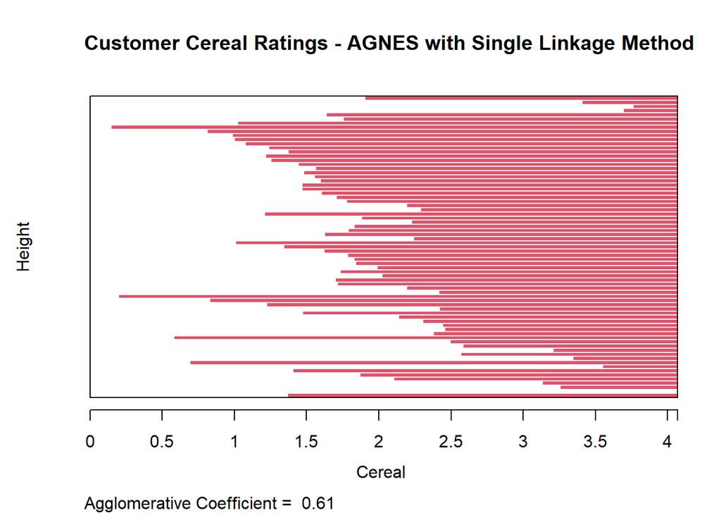

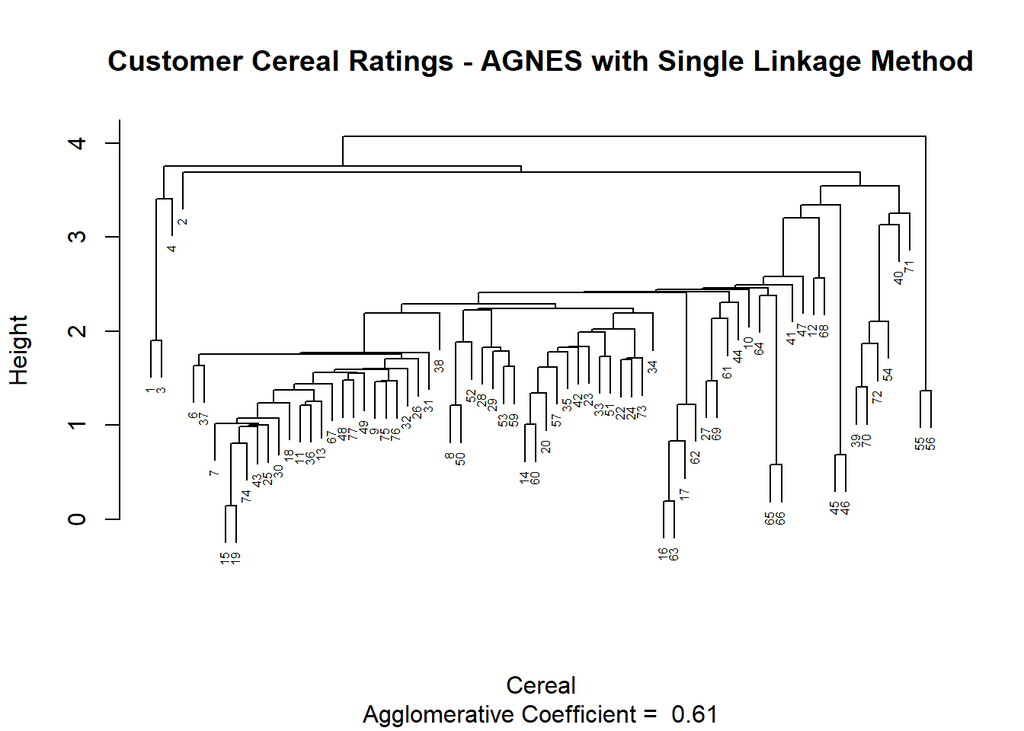

```r
# Euclidean distance measurements are always used to create the dissimilarity matrix for all the numerical values
euclidean_c <- dist(cereals[ , c(4:16)], method = "euclidean")
# The single linkage approach is used to perform a hierarchical clustering.
single_link <- agnes(euclidean_c, method = "single")
# I'm plotting the outcomes of the various techniques here.
plot(single_link,
main = "Customer Cereal Ratings - AGNES with Single Linkage Method",
xlab = "Cereal",
ylab = "Height",
cex.axis = 1,
cex = 0.50)
```

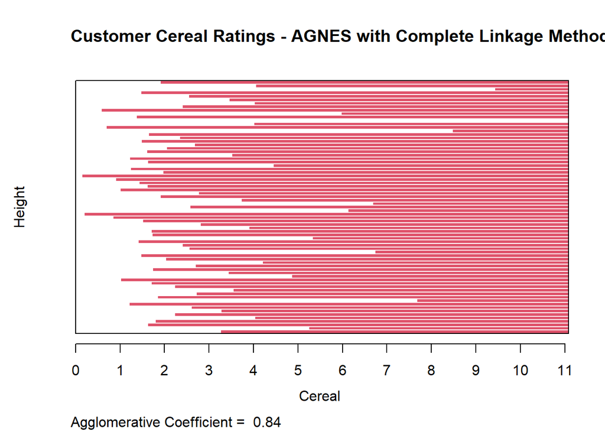

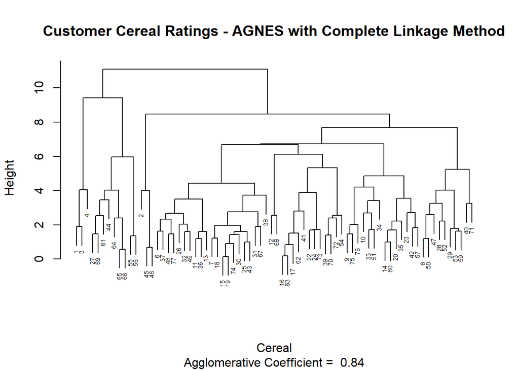

```r
# Making use of the entire linkage approach to perform hierarchical clustering
complete_linkage<- agnes(euclidean_c, method = "complete")
# I'm plotting the outcomes of the various techniques here.
plot(complete_linkage,
main = "Customer Cereal Ratings - AGNES with Complete Linkage Method",
xlab = "Cereal",
ylab = "Height",
cex.axis = 1,
cex = 0.50)
```

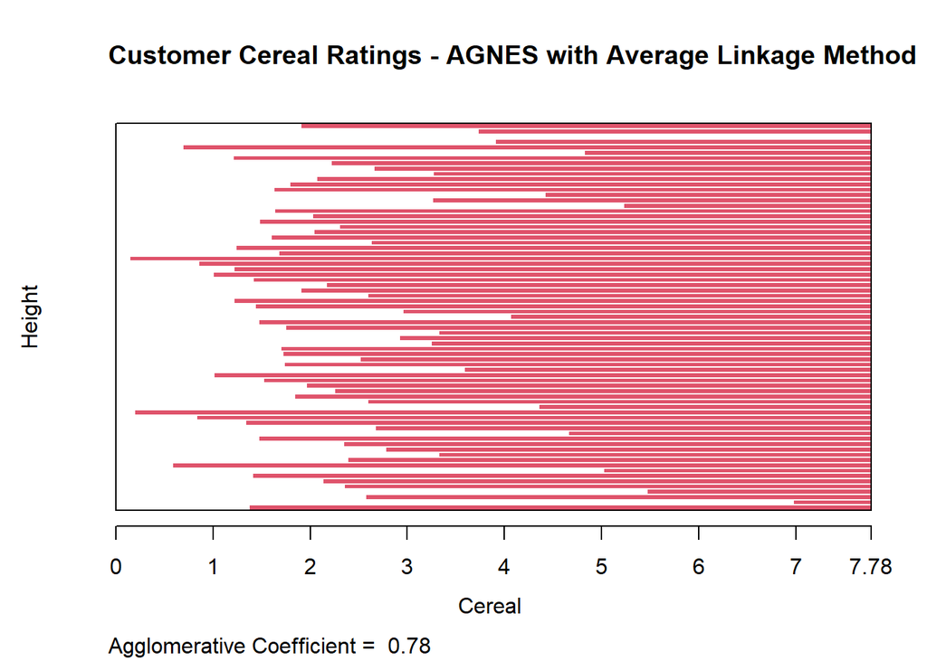

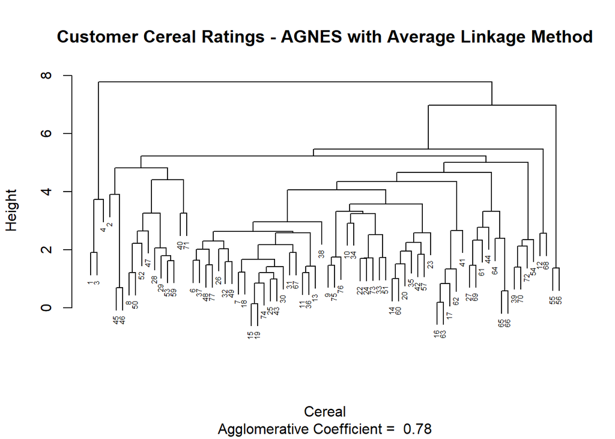

```r
# Performing the average linkage method for hierarchical clustering
average_linkage <- agnes(euclidean_c, method = "average")
# Here I am Plotting the results of the different methods
plot(average_linkage,
main = "Customer Cereal Ratings - AGNES with Average Linkage Method",
xlab = "Cereal",
ylab = "Height",
cex.axis = 1,
cex = 0.50)
```

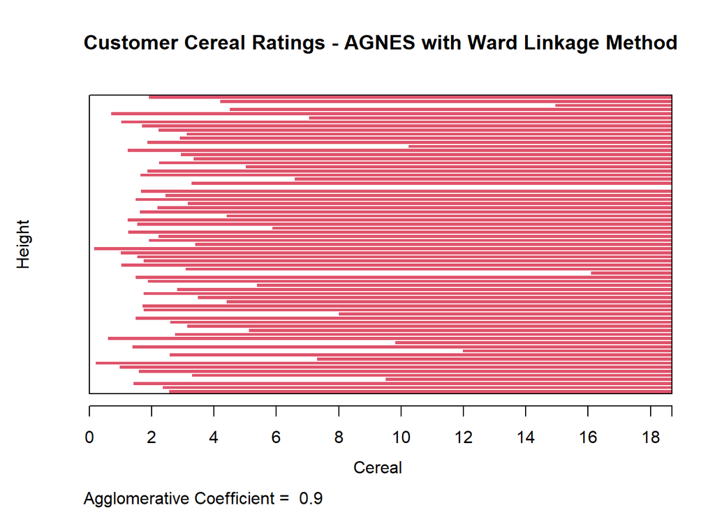

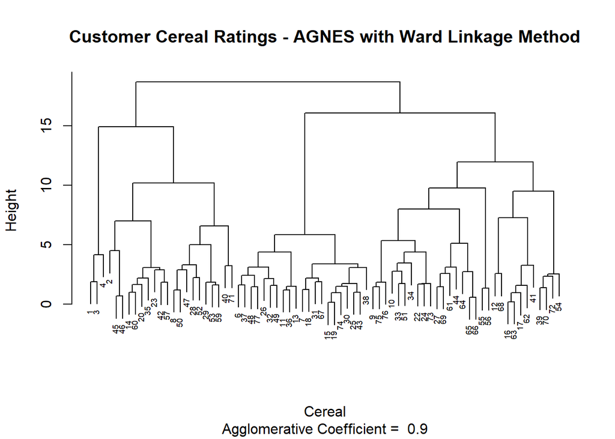

```r
ward_linkage <- agnes(euclidean_c, method = "ward")
# I am Plotting the outcomes of the different methods
plot(ward_linkage,
main = "Customer Cereal Ratings - AGNES with Ward Linkage Method",
xlab = "Cereal",
ylab = "Height",
cex.axis = 1,
cex = 0.55)
```

**Question:** How many clusters would you choose?

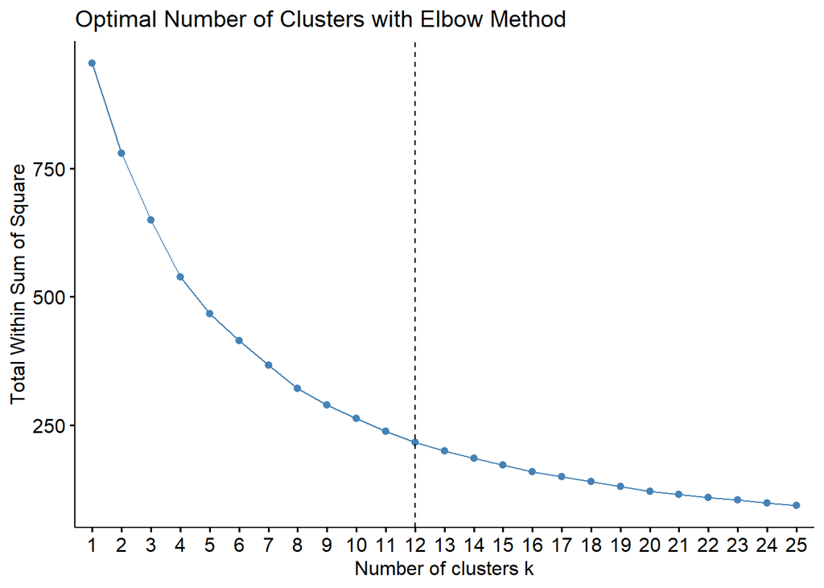

```r
fviz_nbclust(cereals[ , c(4:16)], hcut, method = "wss", k.max = 25) +
labs(title = "Optimal Number of Clusters with Elbow Method") +
geom_vline(xintercept = 12, linetype = 2)
```

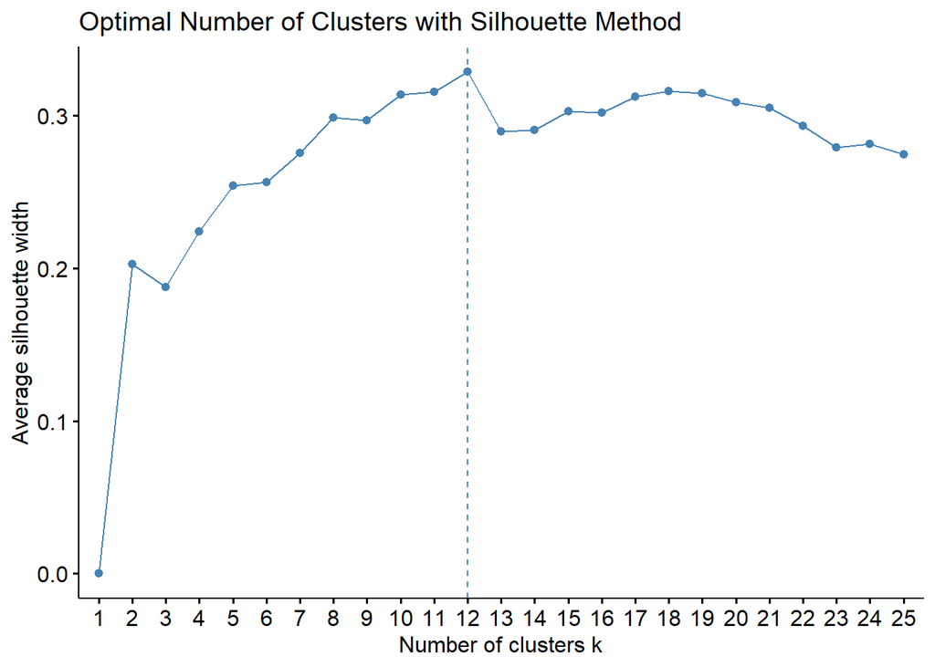

```r
fviz_nbclust(cereals[ , c(4:16)],
hcut,
method = "silhouette",
k.max = 25) +
labs(title = "Optimal Number of Clusters with Silhouette Method")
```

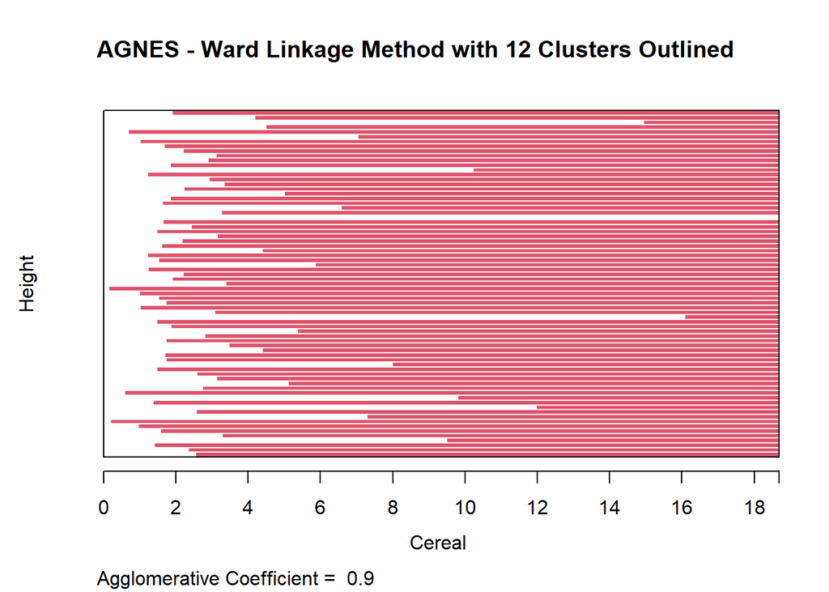

```r
plot(ward_linkage,
main = "AGNES - Ward Linkage Method with 12 Clusters Outlined",
xlab = "Cereal",
ylab = "Height",
cex.axis = 1,
cex = 0.50,)
```

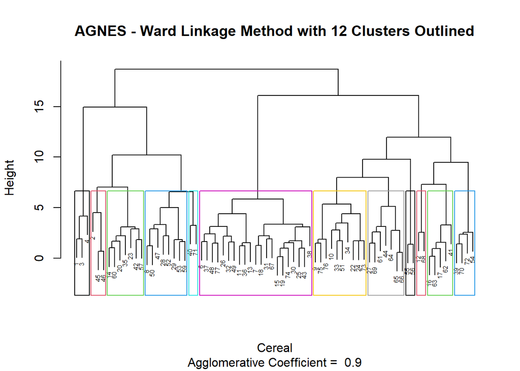

```r
rect.hclust(ward_linkage, k = 12, border = 1:12)
```

**Question**Comment on the structure of the clusters and on their stability. Hint: To check stability, partition the data and see how well clusters formed based on one part apply to the other part. To do this: ● Cluster partition A ● Use the cluster centroids from A to assign each record in partition B (each record is assigned to the cluster with the closest centroid). ● Assess how consistent the cluster assignments are compared to the assignments based on all the dataam

```r
# Cut the tree into 12 clusters for analysis
ward_clusters_12 <- cutree(ward_linkage, k = 12)
# Add the assigned cluster to the pre-processed data set
cereal_preprocessed_1 <- cbind(cluster = ward_clusters_12,
cereals)
# Setting the seed for randomized functions
set.seed(123)
# Split the data into 70% partition A and 30% partition B
cereal_Index <- createDataPartition(cereals$protein, p=0.3, list =
F)
cereal_preprocessed_PartitionB <- cereals[cereal_Index, ]
cereal_preprocessed_PartitionA <- cereals[-cereal_Index,]
```

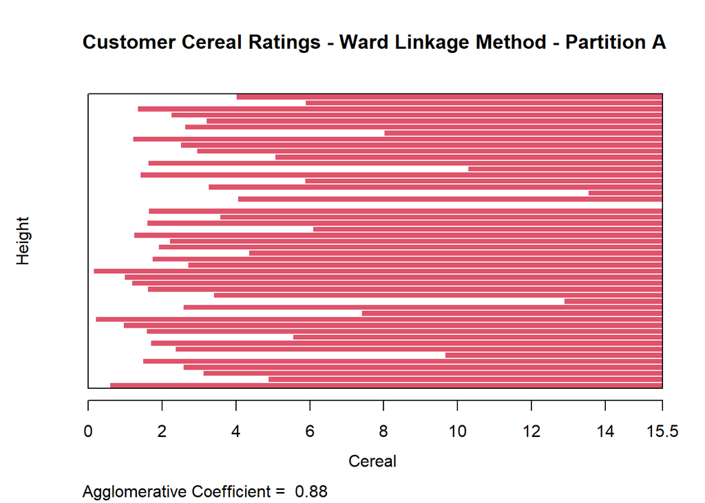

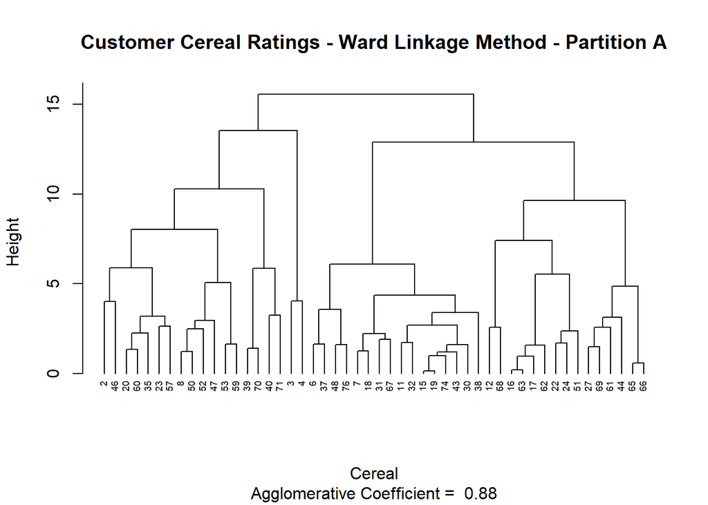

```r
# Create the dissimilarity matrix for the numeric values in the partitioned data set via Euclidean distance measurements
cereal_euclidean_A <- dist(cereal_preprocessed_PartitionA[ , c(4:16)],
method = "euclidean")
# Perform hierarchical clustering via the ward linkage method on partitioned data
ward_a <- agnes(cereal_euclidean_A, method = "ward")
# Plot the results of the different methods
plot(ward_a,
 main = "Customer Cereal Ratings - Ward Linkage Method - Partition A",
 xlab = "Cereal",
 ylab = "Height",
 cex.axis = 1,
 cex = 0.55,
 hang = -1)
```